# The Lady Misappropriating Campaign Funds

## Introduction

Consider two agents: the Lady and the Vegan. The Lady is attempting to take a bogus payment of D dollars, and break it up into `N` chunks that she can “hide” in a larger set of payments. The Vegan is attempting to find which sets of payments the Lady has hidden the `D` dollars in. We will assume that the Vegan knows both the bogus payment amount `D` and the number of chunks it has been broken up into `N`.

The experiment proceeds as follows:

1. We will generate `P` sets of `K` payments from some common distribution
2. For half of the above payment sets, the Lady will randomly partition the `D` dollars into `N` chunks and replace `N` of the `K` “legit” payments in each set with the bogus ones. We will later look at what happens if we change the percentage of payment sets containing bogus chunks.
3. The Vegan will then consider the set of all `P` payments, and based on some classification procedure will have to choose `P`/2 payment sets that they believe contain the bogus payment chunks.

What I aim to do is look at the Vegan’s false-positive and false-negative rates for different values of `D` and for different classification strategies. Obviously the dependence of false-postive and negatives on `D` will also somewhat depend on the underlying payment distribution (like if the “legit” payments are all $1 and `D` = $1e6 then obviously the Vegan’s job will be very easy), but my thinking is that it will not effect the qualtitative performance of different classing strategies.

## Setting up Payment Sets

For now let’s choose `P` = 1000 and `K` = 200. I’m going to just generate them from an exponential distribution with rate parameter $\lambda = 1$ for simplicity.

```r
P <- 1000
K <- 200
payments <- matrix(0, nrow=P, ncol=K)
for (r in 1:P){
  payments[r,] <- rexp(K)
}
```

## The Vegan’s Two Strategies

I’m looking to compare between two specific strategies, both will be based on the following basic idea: for each row in `payments` we can draw `N` random columns and sum them up. If we repeat this `M`=10,000 times we can get an empirical distribution for what the sum of `N` payments “should” look like under “normal spending”, call this sum $S_N$ and its emperical distribtuion $\pi_N$. From here I would like to compare two strategies:

1. We could look at $\pi_N( |S_N - D | < \epsilon )$ and say that a payment set (ie. a row in `payments`) contains the bogus payments if this probability is sufficiently small (say less than $\alpha_1$)
2. We could look at $\pi_N(S_N > D)$ and then say that a payment set contains the bogus payments if this probability is sufficiently small (say less than $\alpha_2$)

```r
is.near <- function(x,y,eps){
  if ( abs(x-y) < eps ){
    return(1)
  }
  else{
    return(0)
  }
}
emp.sums <- function(r,N,M){
  ret <- sapply(1:M, function(m){ sum( sample(r,N,replace=TRUE) ) })
  return(ret)
}
strat.1 <- function(r,D,N,M,eps){
  sums <- emp.sums(r,N,M)
  hits <- sum( sapply( sums, function(x) { is.near(x,D,eps) } ) )
  return( hits/M )
}
strat.2 <- function(r,D,N,M){
  sums <- emp.sums(r,N,M)
  exceeds <- sum( sums > D )
  return( exceeds/M )
}
```

## Comparing the Strategies

### Varying D

#### Average D

For our first case Let’s say `D`=5 and `N`=5. The bogus payments here should “well-hidden” since the average payment in `payments` is 1 so the expected sum of 5 of these payments is 5. This case should be pretty hard for either strategy because nothing really distinguishes the bogus payments from the real ones.

Let’s hide the bogus payments:

```r
chunk <- function(D,N){
  chunks <- runif(N)
  chunks <- chunks/sum(chunks)
  return( D*chunks )
}
D <- 5
N <- 5
for (r in 1:(P/2)){
    payments[r,1:N] <- chunk(D,N)
}
#Note that it doesn't really matter if we shuffle the rows or columns of payments after inserting the bogus chunks. Noth strategies are identical over any permutation of the row since they're just going to randomly sample them anyways
```

Now we’re going to iterate over the `payment` rows and score them in terms of the “bogus-ness” defined by each strategy. For now let’s use a “closeness” value of 1 cent for strategy 1, and we can play around with how this effects its performance later.

```r
M <- 10000
eps.1 <- .01
strat.1.scores <- apply( payments, 1, function(r){ strat.1(r,D,N,M,eps.1) } )
strat.2.scores <- apply( payments, 1, function(r){ strat.2(r,D,N,M)})
```

Okay now since we know that only the first P/2 rows of `payments` actually contained bogus payments, for any given score threshold we can check how many of the second P/2 rows were erroneously flagged to get the number of false-positives. Let’s plot the false-postive performances of each strategy:

```r
false.pos.perc <- function( alpha, scores){
  flagged <- scores[P/2:P] < alpha
  n.erroneous <- sum(flagged)
  return( n.erroneous )
}
alphas <- seq(0,1,.01)
false.pos.1 <- sapply( alphas, function(a) {false.pos.perc(a,strat.1.scores)})
false.pos.2 <- sapply( alphas, function(a) {false.pos.perc(a,strat.2.scores)})
plot( alphas, false.pos.1, type='l', col='blue', xlab='Score Cutoff', ylab='# False Positives')
lines( alphas, false.pos.2, col='red')
```

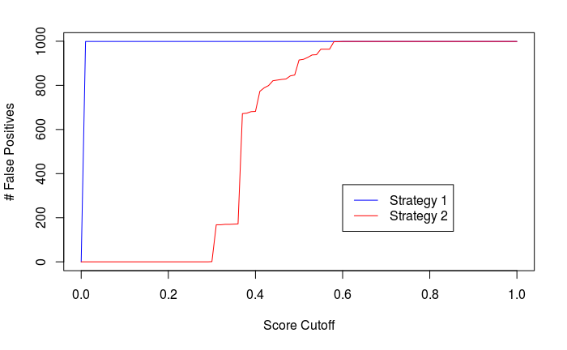

```r
legend( .6,350,legend=c('Strategy 1','Strategy 2'), col=c('blue','red'), lty=1)
```

Okay so Strategy 2 generally produces fewer false positives, although it’s performance is extremely senstivie to the $\alpha$ we choose. For pretty much any cutoff threshold Strategy 1 flags most, if not all of the “good” payments as suspicious. What about false negatives?

```r
false.neg.perc <- function( alpha, scores){
  not.flagged <- scores[1:P/2] > alpha
  n.erroneous <- sum(not.flagged)
  return( n.erroneous )
}
alphas <- seq(0,1,.01)
false.neg.1 <- sapply( alphas, function(a) {false.neg.perc(a,strat.1.scores)})
false.neg.2 <- sapply( alphas, function(a) {false.neg.perc(a,strat.2.scores)})
plot( alphas, false.neg.1, type='l', col='blue', xlab='Score Cutoff', ylab='# False Negatives')
lines( alphas, false.neg.2, col='red')
```

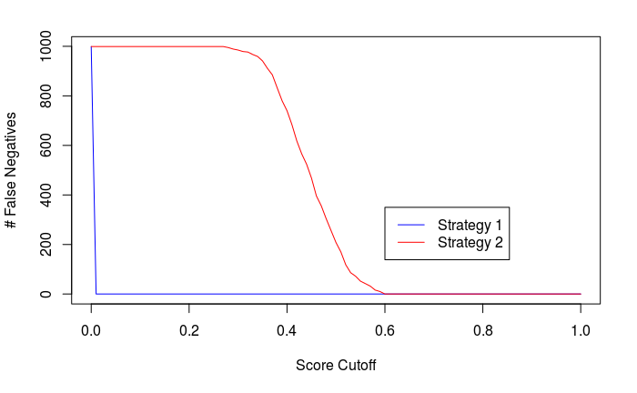

```r
legend( .6,350,legend=c('Strategy 1','Strategy 2'), col=c('blue','red'), lty=1)
```

Interesting, so here we see that Strategy 1 is far better at picking up suspicious payments than Strategy 2. I think this is because it’s just flagging EVERY payment as bogus, so of the set of truly bogus payments it’s just flagging them all. Let’s compare their overall performance in terms of how many they correctly identify…

```r
bogus.rows <- c( rep(1, P/2), rep(0,P/2)  )
correct.perc <- function( alpha, scores){
  flagged <- scores < alpha
  correct <- sum( flagged == bogus.rows )
  return( correct/ length(scores) )
}
alphas <- seq(0,1,.01)
correct.1 <- sapply( alphas, function(a) {correct.perc(a,strat.1.scores)})
correct.2 <- sapply( alphas, function(a) {correct.perc(a,strat.2.scores)})
plot( alphas, correct.1, type='l', col='blue', xlab='Score Cutoff', ylab='Percent Correct')
lines( alphas, correct.2, col='red')
```

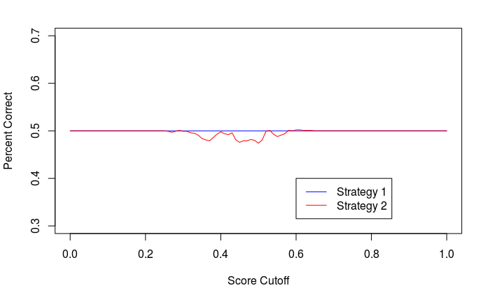

```r
legend( .6,.4, legend=c('Strategy 1','Strategy 2'), col=c('blue','red'), lty=1)
```

Okay so both strategies are performing **basically** the same here (the wiggliness in Strat 2 is just an artifact of the Monte Carlo method; it changes in location, size, and extremity between runs), and that is to say not very well; on average each is doing about as good as random guessing. This makes sense because the payments are “well-hidden”, so neither strategy should realistically be expected to be able to flag a payment as unusual. Let’s see how they do when we make D a lot smaller.

#### Small D

So before D was basically the expected average sum of 5 payments, now let’s make it the expected value of a single payment:

```r
D <- 1
N <- 5
for (r in 1:(P/2)){
  payments[r,1:N] <- chunk(D,N)
}
M <- 10000
eps.1 <- .01
strat.1.scores <- apply( payments, 1, function(r){ strat.1(r,D,N,M,eps.1) } )
strat.2.scores <- apply( payments, 1, function(r){ strat.2(r,D,N,M)})
```

And now here’s the same three graphs as before. False-positive first:

```r
false.pos.1 <- sapply( alphas, function(a) {false.pos.perc(a,strat.1.scores)})
false.pos.2 <- sapply( alphas, function(a) {false.pos.perc(a,strat.2.scores)})
plot( alphas, false.pos.1, type='l', col='blue', xlab='Score Cutoff', ylab='# False Positives')
lines( alphas, false.pos.2, col='red')
```

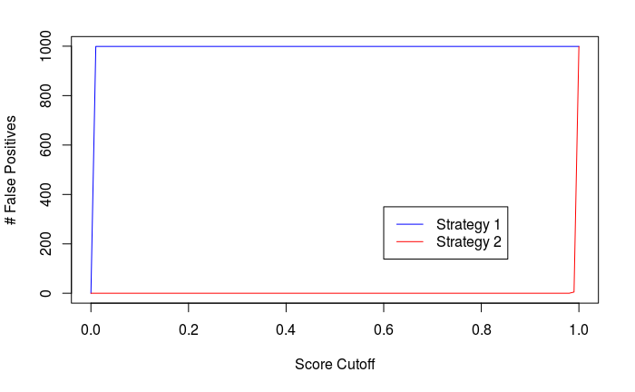

```r
legend( .6,350,legend=c('Strategy 1','Strategy 2'), col=c('blue','red'), lty=1)
```

Again Strategy 2 works better in terms of the FPR, which makes sense because it’s almost always true that $\pi_N(S_n > D) > \pi_n( |S_n - D| < \epsilon )$, so Strategy 2 is in general more conservatie (ie. when Strategy 2 flags a payment set it’s almost certain that Strategy 1 has already flagged it at a lower cutoff threshold). Now false-negatives

```r
false.neg.1 <- sapply( alphas, function(a) {false.neg.perc(a,strat.1.scores)})
false.neg.2 <- sapply( alphas, function(a) {false.neg.perc(a,strat.2.scores)})
plot( alphas, false.neg.1, type='l', col='blue', xlab='Score Cutoff', ylab='# False Negatives')
lines( alphas, false.neg.2, col='red')
```

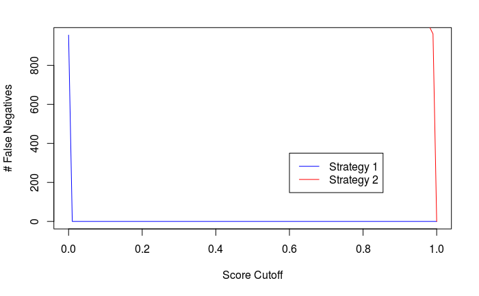

```r
legend( .6,350,legend=c('Strategy 1','Strategy 2'), col=c('blue','red'), lty=1)
```

Same as the case of “well hidden” D, basically Strategy 1 is less conservative so it picks up the bogus payment sets for almost any cutoff value. Now for overall performance:

```r
alphas <- seq(0,1,.01)
correct.1 <- sapply( alphas, function(a) {correct.perc(a,strat.1.scores)})
correct.2 <- sapply( alphas, function(a) {correct.perc(a,strat.2.scores)})
plot( alphas, correct.1, type='l', col='blue', xlab='Score Cutoff', ylab='Percent Correct')
lines( alphas, correct.2, col='red')
```

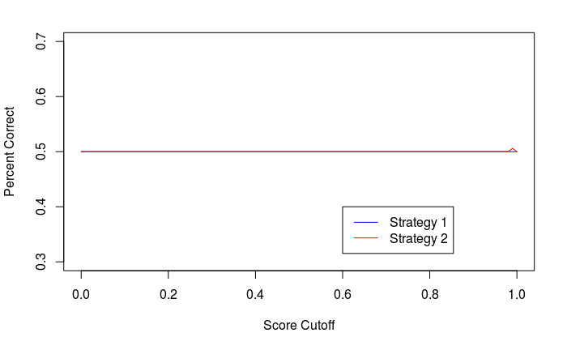

```r
legend( .6,.4, legend=c('Strategy 1','Strategy 2'), col=c('blue','red'), lty=1)
```

Same as for the “well-hidden” case, neither strategy is a great choice because both are about as good as random guessing. Now let’s look at the last case:

#### Large D

```r
D <- 6
N <- 5
for (r in 1:(P/2)){
  payments[r,1:N] <- chunk(D,N)
}
M <- 10000
eps.1 <- .01
strat.1.scores <- apply( payments, 1, function(r){ strat.1(r,D,N,M,eps.1) } )
strat.2.scores <- apply( payments, 1, function(r){ strat.2(r,D,N,M)})
```

I have to say, this case surprised me. I expected Strategy 2 to work much better here, but it turns out that neither strategy is any better than in the previous two cases. Here’s they both act very aggressively, with high FPR and low FNR:

```r
false.pos.1 <- sapply( alphas, function(a) {false.pos.perc(a,strat.1.scores)})
false.pos.2 <- sapply( alphas, function(a) {false.pos.perc(a,strat.2.scores)})
plot( alphas, false.pos.1, type='l', col='blue', xlab='Score Cutoff', ylab='# False Positives')
lines( alphas, false.pos.2, col='red')
```

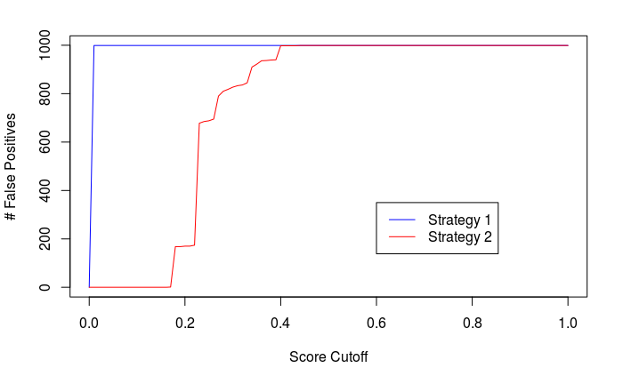

```r
legend( .6,350,legend=c('Strategy 1','Strategy 2'), col=c('blue','red'), lty=1)
```

```r
false.neg.1 <- sapply( alphas, function(a) {false.neg.perc(a,strat.1.scores)})
false.neg.2 <- sapply( alphas, function(a) {false.neg.perc(a,strat.2.scores)})
plot( alphas, false.neg.1, type='l', col='blue', xlab='Score Cutoff', ylab='# False Negatives')
lines( alphas, false.neg.2, col='red')
```

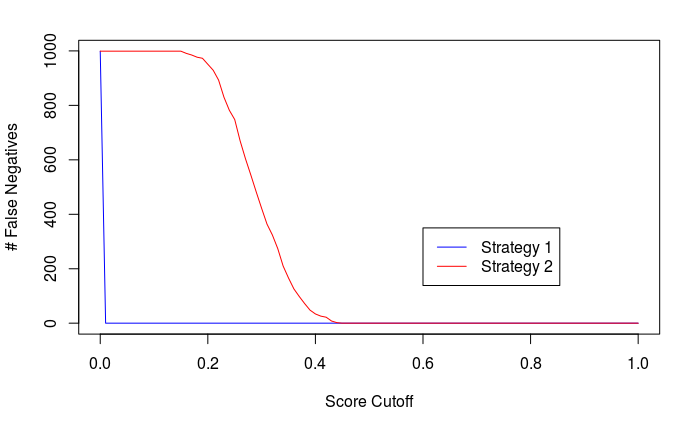

```r
legend( .6,350,legend=c('Strategy 1','Strategy 2'), col=c('blue','red'), lty=1)
```

Neither strategy is any better than random guessing in pretty much any case:

```r
alphas <- seq(0,1,.01)
correct.1 <- sapply( alphas, function(a) {correct.perc(a,strat.1.scores)})
correct.2 <- sapply( alphas, function(a) {correct.perc(a,strat.2.scores)})
plot( alphas, correct.1, type='l', col='blue', xlab='Score Cutoff', ylab='Percent Correct')
lines( alphas, correct.2, col='red')
```

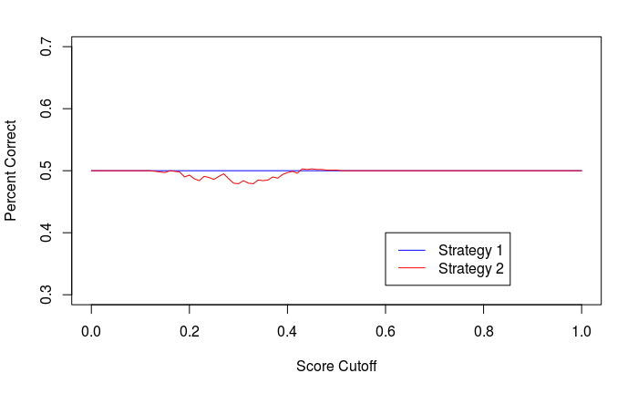

```r
legend( .6,.4, legend=c('Strategy 1','Strategy 2'), col=c('blue','red'), lty=1)
```

I’m going to explore why this is happening in a little bit, but first I’d like to just check if Strat 1 can be improved with a different choice of nuissance parameters.

### How Do Parameters Aside from D Matter?

First off I don’t think $N$ matters very much; I think what’s going to make difference is really D/N, but really looking at the previous cases of varying D/N ratios I don’t think it will effect the performance of either strategy very much at all. Similarly $\epsilon$ seemed important to me at first glance, but the more I think about it the less I think it matters. $\epsilon$ is basically going to control how aggressive Strategy 1 acts, ie. the size of the FPR vs. the FNR. It looks like trying different values of $\epsilon$ varies the tradeoff between these two in such a way that overall performance is basically the same:

```r
D <- 25
N <- 5
for (r in 1:(P/2)){
  payments[r,1:N] <- chunk(D,N)
}
M <- 10000
eps <- seq(.001, .1, .02)
correct.rates <- matrix(0, nrow=length(eps), ncol = length(alphas))
for (i in 1:length(eps)){
  strat.1.scores <- apply( payments, 1, function(r){ strat.1(r,D,N,M,eps[i]) } )
  correct.rates[i,] <- sapply( alphas, function(a) {correct.perc(a,strat.1.scores)})
}
plotting.cols = c('blue','red','green','orange','pink','maroon')
plot(alphas, correct.rates[1,], col=plotting.cols[1], type='l')
for (i in 2:length(eps)){
  lines( alphas, correct.rates[i,], col=plotting.cols[i] )
}
```

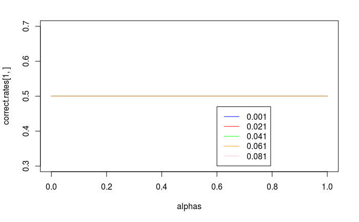

```r
legend( .6,.47, legend=eps, col=plotting.cols[1:length(eps)], lty=1)
```

Even setting epsilon really large, like to D/5, doesn’t change much:

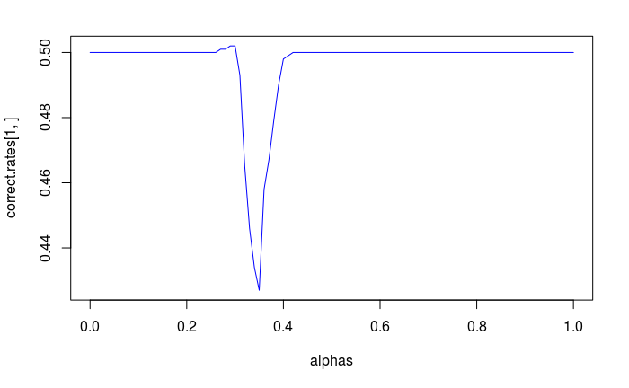

```r
D <- 5
N <- 5
for (r in 1:(P/2)){
  payments[r,1:N] <- chunk(D,N)
}
M <- 10000
eps <- 1
correct.rates <- matrix(0, nrow=length(eps), ncol = length(alphas))
for (i in 1:length(eps)){
  strat.1.scores <- apply( payments, 1, function(r){ strat.1(r,D,N,M,eps[i]) } )
  correct.rates[i,] <- sapply( alphas, function(a) {correct.perc(a,strat.1.scores)})
}
plotting.cols = c('blue','red','green','orange','pink','maroon')
plot(alphas, correct.rates[1,], col=plotting.cols[1], type='l')
```

As far as I can tell, the only thing that will improve the performance of either strategy is change the *base rate* at which bogus payments are inserted into the legit payments. For example, if most payment sets contain bogus payments, than Strategy 1 (being more aggressive) will probably perform a little better than Strategy 2. Similarly if fewer payments sets contain bogus payments then Strategy 2 will probably dominate, because it’s the more conservative strategy. But this does not mean that one strategy is better than the other, this just means that one of the two strategies will always confirm whatever prior beliefs you have about the probability of fraud having occurred in the first place. If you’re confident that fraud occurred, then choose strategy 1, but be aware that any confirmation it gives you is really just a product of the fact that you **already believe that fraud took place**.

### Varying Priors

Let’s see what happens if we change the base amount of bogus payment sets. For brevity I’ll check a case where 75/% of the payment sets contain bogus payments, and a case where 25/% of the sets contain bogus payments.

```r
payments <- matrix(0, nrow=P, ncol=K)
for (r in 1:P){
  payments[r,] <- rexp(K)
}
fraud.likely <- payments
fraud.unlikely <- payments
D <- 5
N <- 5
#Fraud occurs in 1/4 of the payment sets
for (r in 1:(P/4)){
    fraud.likely[r,1:N] <- chunk(D,N)
}
#Fraud occurs in 3/4 of the payment sets
for (r in 1:(3*P/4)){
    fraud.likely[r,1:N] <- chunk(D,N)
}
for (r in 1:(P/2)){
  payments[r,1:N] <- chunk(D,N)
}
M <- 10000
eps.1 <- .01
likely.1 <- apply( fraud.likely, 1, function(r){ strat.1(r,D,N,M,eps.1) } )
likely.2 <- apply( fraud.likely, 1, function(r){ strat.2(r,D,N,M)})
unlikely.1 <- apply( fraud.unlikely, 1, function(r){ strat.1(r,D,N,M,eps.1) } )
unlikely.2 <- apply( fraud.unlikely, 1, function(r){ strat.2(r,D,N,M)})
bogus.rows.likely <- c( rep(1, 3*P/4), rep(0,P/4)  )
bogus.rows.unlikely <- c( rep(1, P/4), rep(0,3*P/4) )
correct.likely <- function( alpha, scores){
  flagged <- scores < alpha
  correct <- sum( flagged == bogus.rows.likely )
  return( correct/ length(scores) )
}
correct.unlikely <- function( alpha, scores){
  flagged <- scores < alpha
  correct <- sum( flagged == bogus.rows.unlikely )
  return( correct/ length(scores) )
}
alphas <- seq(0,1,.01)
correct.1.likely <- sapply( alphas, function(a) {correct.likely(a,likely.1)})
correct.2.likely <- sapply( alphas, function(a) {correct.likely(a,likely.2)})
correct.1.unlikely <- sapply( alphas, function(a) {correct.unlikely(a,unlikely.1)})
correct.2.unlikely <- sapply( alphas, function(a) {correct.unlikely(a,unlikely.2)})
plot( alphas, correct.1.likely, type='l', col='blue', xlab='Score Cutoff', ylab='Percent Correct', main="75% Prob of Fraud")
lines( alphas, correct.2.likely, col='red')
```

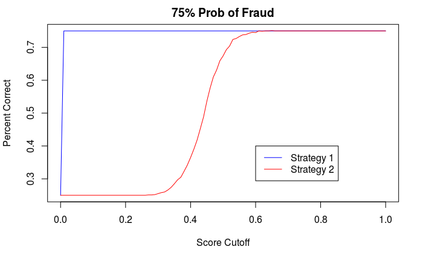

```r
legend( .6,.4, legend=c('Strategy 1','Strategy 2'), col=c('blue','red'), lty=1)
```

```r
plot( alphas, correct.1.unlikely, type='l', col='blue', xlab='Score Cutoff', ylab='Percent Correct', main="25% Prob of Fraud")
lines( alphas, correct.2.unlikely, col='red')
```

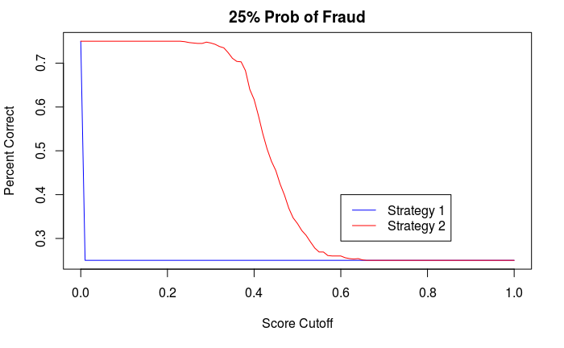

```r
legend( .6,.4, legend=c('Strategy 1','Strategy 2'), col=c('blue','red'), lty=1)
```

In the case where it’s appropriate to be conservative, the conservative strategy works better. In the case where it’s appropriate to be aggressive, the aggressive strategy does better. The choice of strategy is basically a “forking path” type choice, depending on whether your prior belief is that its important to be conservative or aggressive. This means that inference is not working here, to see this more clearly let’s do a more proper “Bayesian”" analysis of the probability of fraud occurring, given that a strategy has flagged a payment set as fraudulent:

#### Strategy 1

```r
prob.strat.says.fraud.given.fraud <- function( alpha, scores){
  correct<- sum( scores[1:(3*P/4)] < alpha )
  return( correct/(3*P/4) )
}
print("Pr[strat 1 says fraud | fraud] =")
```

```
[1] "Pr[strat 1 says fraud | fraud] ="
```

```r
prob.strat.says.fraud.given.fraud( .1, likely.1 )
```

```
[1] 1
```

```r
print("Pr[strat 1 says fraud] =")
```

```
[1] "Pr[strat 1 says fraud] ="
```

```r
sum( likely.1 < .01 )/length(likely.1)
```

```
[1] 1
```

So basically, at it’s peak performance, Strategy 1 is just classifying everything as Fraud. This means that:
$$Pr[ \text{ fraud } | \text{ strat 1 says fraud } ] = \frac{ Pr[ \text{ strat 1 says fraud } | \text{ fraud } ] Pr[ \text{ fraud } ] }{ Pr[ \text{ strat 1 says fraud } ] } = \frac{ 1 *. 75}{1} = .75$$

Now let’s see the case where $Pr[ \text{fraud} ] = .25$::

```r
prob.strat.says.fraud.given.fraud <- function( alpha, scores){
  correct<- sum( scores[1:(P/4)] < alpha )
  return( correct/(P/4) )
}
print("Pr[strat 1 says fraud | fraud] =")
```

```
[1] "Pr[strat 1 says fraud | fraud] ="
```

```r
prob.strat.says.fraud.given.fraud( .1, unlikely.1 )
```

```
[1] 1
```

```r
print("Pr[strat 1 says fraud] =")
```

```
[1] "Pr[strat 1 says fraud] ="
```

```r
sum( unlikely.1 < .01 )/length(unlikely.1)
```

```
[1] 1
```

Same thing; since Strategy 1 just always says “fraud” our posterior probability of fraud just exactly equal to our prior. Our model is outputting precisely the information we put into it, without adding anything new.

I could redo this analysis for Strategy 2, but I’m pretty convinced that it will behave identically. Neither of these strategies are going to be useful for determining if bogus payments are present in a set.

## Conclusions

So based on all this I think a step needs to be taken back to the common premise of these two strategies: as far as I can tell the problem here is that you’re trying to say that it’s unusual that
$$S_n \approx D$$
, and you’re doing so by resampling the previous payments. It looks like classing strategies based on this approach will ultimately just confirm whatever prior beliefs you have about fraud occurring in the first place, and if you already hold strong beliefs about the presence of fraud why do you need to do the analysis in the first place? I think what needs to be done is actually compare the properties of payments themselves that sum to D, rather than just considering the fact that they sum to D. Looking back I think the reason why these methods don’t work is clear: it’s basically a circular argument. You’re trying to test the hypothesis that “these payments, which are unusual for reason A, are unusual for reason A”. You’re just begging the question, not making a statistical argument. Alternatively this problem can be viewed as analagous to performing hypothesis testing about the distribution of $S_N$ with only a single observation, D. A single observation adds no new info to your beliefs about the distribution of $S_N$.

So what can be done? Well I think you need to inject more information into the problem. You’ve identified that these payments are interesting because they sum to D, so now what you need to do is find other ways that they might be unusual: 1. Look at their distribution in time relative to other payments by the campaign: are they unusually clustered? Were there other payments made that close to the Stormy Daniels settlement?  
2. Looking at the amount of the individual payments. Were they unusually large or small, how often do you see 4 payments of the exact same amount made on the same day? These would sidestep this issue of circularity, because now you’re testing the hypothesis “these payments, which are unusual for reason A, are unusual for reasons B,C,D…” where B,C,D are in some way relevant to the payments being bogus.